# Risk Factor Analysis

## Outcome Variable

**Outcome Variable:** swasted

## Predictor Variables

**Intervention Variable:** meducyrs

**Adjustment Set:**

unadjusted

## Stratifying Variables

The analysis was stratified on these variable(s):

- agecat
- studyid
- country

## Data Summary

| agecat | studyid | country | meducyrs | swasted | n_cell | n | outcome_variable |
| --- | --- | --- | --- | --- | --- | --- | --- |
| Birth | ki0047075b-MAL-ED | BANGLADESH | High | 0 | 63 | 175 | swasted |
| Birth | ki0047075b-MAL-ED | BANGLADESH | High | 1 | 1 | 175 | swasted |
| Birth | ki0047075b-MAL-ED | BANGLADESH | Low | 0 | 58 | 175 | swasted |
| Birth | ki0047075b-MAL-ED | BANGLADESH | Low | 1 | 2 | 175 | swasted |
| Birth | ki0047075b-MAL-ED | BANGLADESH | Medium | 0 | 48 | 175 | swasted |
| Birth | ki0047075b-MAL-ED | BANGLADESH | Medium | 1 | 3 | 175 | swasted |
| Birth | ki0047075b-MAL-ED | BRAZIL | High | 0 | 18 | 62 | swasted |
| Birth | ki0047075b-MAL-ED | BRAZIL | High | 1 | 0 | 62 | swasted |
| Birth | ki0047075b-MAL-ED | BRAZIL | Low | 0 | 17 | 62 | swasted |
| Birth | ki0047075b-MAL-ED | BRAZIL | Low | 1 | 0 | 62 | swasted |
| Birth | ki0047075b-MAL-ED | BRAZIL | Medium | 0 | 27 | 62 | swasted |
| Birth | ki0047075b-MAL-ED | BRAZIL | Medium | 1 | 0 | 62 | swasted |
| Birth | ki0047075b-MAL-ED | INDIA | High | 0 | 8 | 38 | swasted |
| Birth | ki0047075b-MAL-ED | INDIA | High | 1 | 0 | 38 | swasted |
| Birth | ki0047075b-MAL-ED | INDIA | Low | 0 | 18 | 38 | swasted |
| Birth | ki0047075b-MAL-ED | INDIA | Low | 1 | 0 | 38 | swasted |
| Birth | ki0047075b-MAL-ED | INDIA | Medium | 0 | 12 | 38 | swasted |
| Birth | ki0047075b-MAL-ED | INDIA | Medium | 1 | 0 | 38 | swasted |
| Birth | ki0047075b-MAL-ED | NEPAL | High | 0 | 4 | 24 | swasted |
| Birth | ki0047075b-MAL-ED | NEPAL | High | 1 | 1 | 24 | swasted |
| Birth | ki0047075b-MAL-ED | NEPAL | Low | 0 | 12 | 24 | swasted |
| Birth | ki0047075b-MAL-ED | NEPAL | Low | 1 | 0 | 24 | swasted |
| Birth | ki0047075b-MAL-ED | NEPAL | Medium | 0 | 7 | 24 | swasted |
| Birth | ki0047075b-MAL-ED | NEPAL | Medium | 1 | 0 | 24 | swasted |
| Birth | ki0047075b-MAL-ED | PERU | High | 0 | 65 | 228 | swasted |
| Birth | ki0047075b-MAL-ED | PERU | High | 1 | 0 | 228 | swasted |
| Birth | ki0047075b-MAL-ED | PERU | Low | 0 | 83 | 228 | swasted |
| Birth | ki0047075b-MAL-ED | PERU | Low | 1 | 0 | 228 | swasted |
| Birth | ki0047075b-MAL-ED | PERU | Medium | 0 | 80 | 228 | swasted |
| Birth | ki0047075b-MAL-ED | PERU | Medium | 1 | 0 | 228 | swasted |

[output cut: 396 more lines]

The following strata were considered:

- agecat: 24 months, studyid: ki0047075b-MAL-ED, country: BANGLADESH
- agecat: 24 months, studyid: ki0047075b-MAL-ED, country: BRAZIL
- agecat: 24 months, studyid: ki0047075b-MAL-ED, country: INDIA
- agecat: 24 months, studyid: ki0047075b-MAL-ED, country: NEPAL
- agecat: 24 months, studyid: ki0047075b-MAL-ED, country: PERU
- agecat: 24 months, studyid: ki0047075b-MAL-ED, country: SOUTH AFRICA
- agecat: 24 months, studyid: ki0047075b-MAL-ED, country: TANZANIA, UNITED REPUBLIC OF
- agecat: 24 months, studyid: ki1000108-CMC-V-BCS-2002, country: INDIA
- agecat: 24 months, studyid: ki1000108-IRC, country: INDIA
- agecat: 24 months, studyid: ki1000109-EE, country: PAKISTAN
- agecat: 24 months, studyid: ki1017093-NIH-Birth, country: BANGLADESH
- agecat: 24 months, studyid: ki1017093b-PROVIDE, country: BANGLADESH
- agecat: 24 months, studyid: ki1017093c-NIH-Crypto, country: BANGLADESH
- agecat: 24 months, studyid: ki1066203-TanzaniaChild2, country: TANZANIA, UNITED REPUBLIC OF
- agecat: 24 months, studyid: ki1113344-GMS-Nepal, country: NEPAL
- agecat: 24 months, studyid: ki1119695-PROBIT, country: BELARUS
- agecat: 24 months, studyid: ki1126311-ZVITAMBO, country: ZIMBABWE
- agecat: 24 months, studyid: ki1135781-COHORTS, country: GUATEMALA
- agecat: 24 months, studyid: ki1135781-COHORTS, country: INDIA
- agecat: 24 months, studyid: ki1135781-COHORTS, country: PHILIPPINES
- agecat: 24 months, studyid: ki1148112-LCNI-5, country: MALAWI
- agecat: 24 months, studyid: kiGH5241-JiVitA-3, country: BANGLADESH
- agecat: 24 months, studyid: kiGH5241-JiVitA-4, country: BANGLADESH
- agecat: 6 months, studyid: ki0047075b-MAL-ED, country: BANGLADESH
- agecat: 6 months, studyid: ki0047075b-MAL-ED, country: BRAZIL
- agecat: 6 months, studyid: ki0047075b-MAL-ED, country: INDIA
- agecat: 6 months, studyid: ki0047075b-MAL-ED, country: NEPAL
- agecat: 6 months, studyid: ki0047075b-MAL-ED, country: PERU
- agecat: 6 months, studyid: ki0047075b-MAL-ED, country: SOUTH AFRICA
- agecat: 6 months, studyid: ki0047075b-MAL-ED, country: TANZANIA, UNITED REPUBLIC OF
- agecat: 6 months, studyid: ki1000108-CMC-V-BCS-2002, country: INDIA
- agecat: 6 months, studyid: ki1000108-IRC, country: INDIA
- agecat: 6 months, studyid: ki1000109-EE, country: PAKISTAN
- agecat: 6 months, studyid: ki1000304b-SAS-CompFeed, country: INDIA
- agecat: 6 months, studyid: ki1000304b-SAS-FoodSuppl, country: INDIA
- agecat: 6 months, studyid: ki1017093-NIH-Birth, country: BANGLADESH
- agecat: 6 months, studyid: ki1017093b-PROVIDE, country: BANGLADESH
- agecat: 6 months, studyid: ki1017093c-NIH-Crypto, country: BANGLADESH
- agecat: 6 months, studyid: ki1066203-TanzaniaChild2, country: TANZANIA, UNITED REPUBLIC OF
- agecat: 6 months, studyid: ki1112895-Guatemala BSC, country: GUATEMALA
- agecat: 6 months, studyid: ki1113344-GMS-Nepal, country: NEPAL
- agecat: 6 months, studyid: ki1119695-PROBIT, country: BELARUS
- agecat: 6 months, studyid: ki1126311-ZVITAMBO, country: ZIMBABWE
- agecat: 6 months, studyid: ki1135781-COHORTS, country: GUATEMALA
- agecat: 6 months, studyid: ki1135781-COHORTS, country: INDIA
- agecat: 6 months, studyid: ki1135781-COHORTS, country: PHILIPPINES
- agecat: 6 months, studyid: ki1148112-LCNI-5, country: MALAWI
- agecat: 6 months, studyid: kiGH5241-JiVitA-3, country: BANGLADESH
- agecat: 6 months, studyid: kiGH5241-JiVitA-4, country: BANGLADESH
- agecat: Birth, studyid: ki0047075b-MAL-ED, country: BANGLADESH
- agecat: Birth, studyid: ki0047075b-MAL-ED, country: BRAZIL
- agecat: Birth, studyid: ki0047075b-MAL-ED, country: INDIA
- agecat: Birth, studyid: ki0047075b-MAL-ED, country: NEPAL
- agecat: Birth, studyid: ki0047075b-MAL-ED, country: PERU
- agecat: Birth, studyid: ki0047075b-MAL-ED, country: SOUTH AFRICA
- agecat: Birth, studyid: ki0047075b-MAL-ED, country: TANZANIA, UNITED REPUBLIC OF
- agecat: Birth, studyid: ki1000108-CMC-V-BCS-2002, country: INDIA
- agecat: Birth, studyid: ki1000108-IRC, country: INDIA
- agecat: Birth, studyid: ki1000109-EE, country: PAKISTAN
- agecat: Birth, studyid: ki1000304b-SAS-CompFeed, country: INDIA
- agecat: Birth, studyid: ki1017093-NIH-Birth, country: BANGLADESH
- agecat: Birth, studyid: ki1017093b-PROVIDE, country: BANGLADESH
- agecat: Birth, studyid: ki1017093c-NIH-Crypto, country: BANGLADESH
- agecat: Birth, studyid: ki1113344-GMS-Nepal, country: NEPAL
- agecat: Birth, studyid: ki1119695-PROBIT, country: BELARUS
- agecat: Birth, studyid: ki1126311-ZVITAMBO, country: ZIMBABWE
- agecat: Birth, studyid: ki1135781-COHORTS, country: GUATEMALA
- agecat: Birth, studyid: ki1135781-COHORTS, country: INDIA
- agecat: Birth, studyid: ki1135781-COHORTS, country: PHILIPPINES
- agecat: Birth, studyid: kiGH5241-JiVitA-3, country: BANGLADESH
- agecat: Birth, studyid: kiGH5241-JiVitA-4, country: BANGLADESH

### Dropped Strata

Some strata were dropped due to rare outcomes:

- agecat: Birth, studyid: ki0047075b-MAL-ED, country: BANGLADESH
- agecat: Birth, studyid: ki0047075b-MAL-ED, country: BRAZIL
- agecat: Birth, studyid: ki0047075b-MAL-ED, country: INDIA
- agecat: Birth, studyid: ki0047075b-MAL-ED, country: NEPAL
- agecat: Birth, studyid: ki0047075b-MAL-ED, country: PERU
- agecat: Birth, studyid: ki0047075b-MAL-ED, country: SOUTH AFRICA
- agecat: Birth, studyid: ki0047075b-MAL-ED, country: TANZANIA, UNITED REPUBLIC OF
- agecat: Birth, studyid: ki1000108-CMC-V-BCS-2002, country: INDIA
- agecat: Birth, studyid: ki1000109-EE, country: PAKISTAN
- agecat: Birth, studyid: ki1000304b-SAS-CompFeed, country: INDIA
- agecat: Birth, studyid: ki1017093b-PROVIDE, country: BANGLADESH
- agecat: 6 months, studyid: ki0047075b-MAL-ED, country: BANGLADESH
- agecat: 6 months, studyid: ki0047075b-MAL-ED, country: BRAZIL
- agecat: 6 months, studyid: ki0047075b-MAL-ED, country: INDIA
- agecat: 6 months, studyid: ki0047075b-MAL-ED, country: NEPAL
- agecat: 6 months, studyid: ki0047075b-MAL-ED, country: PERU
- agecat: 6 months, studyid: ki0047075b-MAL-ED, country: SOUTH AFRICA
- agecat: 6 months, studyid: ki0047075b-MAL-ED, country: TANZANIA, UNITED REPUBLIC OF
- agecat: 6 months, studyid: ki1000108-CMC-V-BCS-2002, country: INDIA
- agecat: 6 months, studyid: ki1000109-EE, country: PAKISTAN
- agecat: 6 months, studyid: ki1000304b-SAS-CompFeed, country: INDIA
- agecat: 6 months, studyid: ki1000304b-SAS-FoodSuppl, country: INDIA
- agecat: 6 months, studyid: ki1017093-NIH-Birth, country: BANGLADESH
- agecat: 6 months, studyid: ki1017093b-PROVIDE, country: BANGLADESH
- agecat: 6 months, studyid: ki1017093c-NIH-Crypto, country: BANGLADESH
- agecat: 6 months, studyid: ki1066203-TanzaniaChild2, country: TANZANIA, UNITED REPUBLIC OF
- agecat: 6 months, studyid: ki1112895-Guatemala BSC, country: GUATEMALA
- agecat: 6 months, studyid: ki1113344-GMS-Nepal, country: NEPAL
- agecat: 6 months, studyid: ki1119695-PROBIT, country: BELARUS
- agecat: 6 months, studyid: ki1135781-COHORTS, country: GUATEMALA
- agecat: 6 months, studyid: ki1148112-LCNI-5, country: MALAWI
- agecat: 6 months, studyid: kiGH5241-JiVitA-4, country: BANGLADESH
- agecat: 24 months, studyid: ki0047075b-MAL-ED, country: BANGLADESH
- agecat: 24 months, studyid: ki0047075b-MAL-ED, country: BRAZIL
- agecat: 24 months, studyid: ki0047075b-MAL-ED, country: INDIA
- agecat: 24 months, studyid: ki0047075b-MAL-ED, country: NEPAL
- agecat: 24 months, studyid: ki0047075b-MAL-ED, country: PERU
- agecat: 24 months, studyid: ki0047075b-MAL-ED, country: SOUTH AFRICA
- agecat: 24 months, studyid: ki0047075b-MAL-ED, country: TANZANIA, UNITED REPUBLIC OF
- agecat: 24 months, studyid: ki1000108-CMC-V-BCS-2002, country: INDIA
- agecat: 24 months, studyid: ki1000108-IRC, country: INDIA
- agecat: 24 months, studyid: ki1000109-EE, country: PAKISTAN
- agecat: 24 months, studyid: ki1017093-NIH-Birth, country: BANGLADESH
- agecat: 24 months, studyid: ki1017093b-PROVIDE, country: BANGLADESH
- agecat: 24 months, studyid: ki1017093c-NIH-Crypto, country: BANGLADESH
- agecat: 24 months, studyid: ki1066203-TanzaniaChild2, country: TANZANIA, UNITED REPUBLIC OF
- agecat: 24 months, studyid: ki1113344-GMS-Nepal, country: NEPAL
- agecat: 24 months, studyid: ki1119695-PROBIT, country: BELARUS
- agecat: 24 months, studyid: ki1135781-COHORTS, country: GUATEMALA
- agecat: 24 months, studyid: ki1135781-COHORTS, country: INDIA
- agecat: 24 months, studyid: ki1148112-LCNI-5, country: MALAWI

## Methods Detail

We’re interested in the causal parameters $E[Y_a]$ for all values of $a \in \mathcal{A}$. These parameters represent the mean outcome if, possibly contrary to fact, we intervened to set all units to have $A=a$. Under the randomization and positivity assumptions, these are identified by the statistical parameters $\psi_a=E_W[E_{Y|A,W}(Y|A=a,W)]$. In addition, we’re interested in the mean of $Y$, $E[Y]$ under no intervention (the observed mean). We will estimate these parameters by using SuperLearner to fit the relevant likelihood factors – $E_{Y|A,W}(Y|A=a,W)$ and $p(A=a|W)$, and then updating our likelihood fit using a joint TMLE.

For unadjusted analyses ($W=\{\}$), initial likelihoods were estimated using Lrnr_glm to estimate the simple $E(Y|A)$ and Lrnr_mean to estimate $p(A)$. For adjusted analyses, a small library containing Lrnr_glmnet, Lrnr_xgboost, and Lrnr_mean was used.

Having estimated these parameters, we will then use the delta method to estimate relative risks and attributable risks relative to a prespecified baseline level of $A$.

# Results Detail

## Results Plots

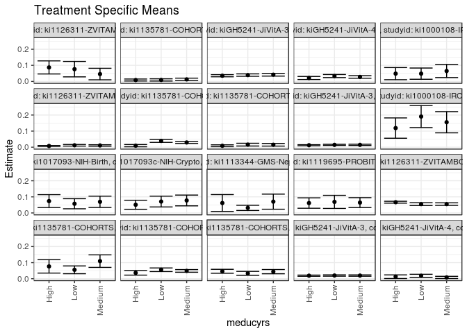

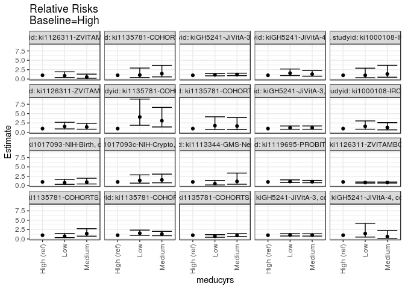

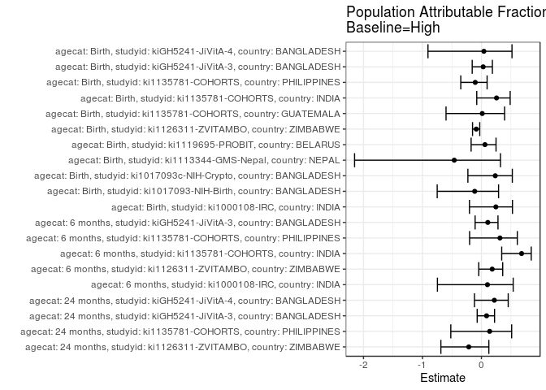

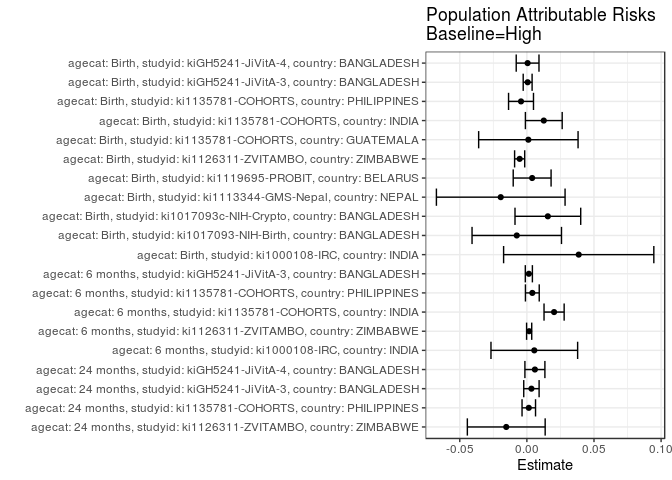

## Results Table

### Parameter: TSM

| agecat | studyid | country | intervention_level | baseline_level | estimate | ci_lower | ci_upper |
| --- | --- | --- | --- | --- | --- | --- | --- |
| Birth | ki1000108-IRC | INDIA | High | NA | 0.1188119 | 0.0556165 | 0.1820073 |
| Birth | ki1000108-IRC | INDIA | Low | NA | 0.1904762 | 0.1218117 | 0.2591406 |
| Birth | ki1000108-IRC | INDIA | Medium | NA | 0.1551724 | 0.0891875 | 0.2211573 |
| Birth | ki1017093-NIH-Birth | BANGLADESH | High | NA | 0.0736196 | 0.0334938 | 0.1137454 |
| Birth | ki1017093-NIH-Birth | BANGLADESH | Low | NA | 0.0571429 | 0.0257218 | 0.0885639 |
| Birth | ki1017093-NIH-Birth | BANGLADESH | Medium | NA | 0.0693069 | 0.0342526 | 0.1043613 |
| Birth | ki1017093c-NIH-Crypto | BANGLADESH | High | NA | 0.0508475 | 0.0227994 | 0.0788955 |
| Birth | ki1017093c-NIH-Crypto | BANGLADESH | Low | NA | 0.0707965 | 0.0373336 | 0.1042593 |
| Birth | ki1017093c-NIH-Crypto | BANGLADESH | Medium | NA | 0.0775510 | 0.0440362 | 0.1110659 |
| Birth | ki1113344-GMS-Nepal | NEPAL | High | NA | 0.0617284 | 0.0092776 | 0.1141792 |
| Birth | ki1113344-GMS-Nepal | NEPAL | Low | NA | 0.0315315 | 0.0152644 | 0.0477987 |
| Birth | ki1113344-GMS-Nepal | NEPAL | Medium | NA | 0.0701754 | 0.0232478 | 0.1171031 |
| Birth | ki1119695-PROBIT | BELARUS | High | NA | 0.0615797 | 0.0292120 | 0.0939473 |
| Birth | ki1119695-PROBIT | BELARUS | Low | NA | 0.0687702 | 0.0280863 | 0.1094542 |
| Birth | ki1119695-PROBIT | BELARUS | Medium | NA | 0.0644093 | 0.0336774 | 0.0951413 |
| Birth | ki1126311-ZVITAMBO | ZIMBABWE | High | NA | 0.0667142 | 0.0608748 | 0.0725536 |
| Birth | ki1126311-ZVITAMBO | ZIMBABWE | Low | NA | 0.0548758 | 0.0462805 | 0.0634711 |
| Birth | ki1126311-ZVITAMBO | ZIMBABWE | Medium | NA | 0.0549451 | 0.0470309 | 0.0628592 |
| Birth | ki1135781-COHORTS | GUATEMALA | High | NA | 0.0764331 | 0.0348455 | 0.1180207 |
| Birth | ki1135781-COHORTS | GUATEMALA | Low | NA | 0.0552326 | 0.0310769 | 0.0793882 |
| Birth | ki1135781-COHORTS | GUATEMALA | Medium | NA | 0.1093117 | 0.0703726 | 0.1482509 |
| Birth | ki1135781-COHORTS | INDIA | High | NA | 0.0365854 | 0.0222172 | 0.0509535 |
| Birth | ki1135781-COHORTS | INDIA | Low | NA | 0.0555556 | 0.0443376 | 0.0667735 |
| Birth | ki1135781-COHORTS | INDIA | Medium | NA | 0.0484548 | 0.0402335 | 0.0566761 |
| Birth | ki1135781-COHORTS | PHILIPPINES | High | NA | 0.0460993 | 0.0338597 | 0.0583389 |
| Birth | ki1135781-COHORTS | PHILIPPINES | Low | NA | 0.0334129 | 0.0212432 | 0.0455825 |
| Birth | ki1135781-COHORTS | PHILIPPINES | Medium | NA | 0.0439443 | 0.0307897 | 0.0570988 |
| Birth | kiGH5241-JiVitA-3 | BANGLADESH | High | NA | 0.0188244 | 0.0150829 | 0.0225658 |
| Birth | kiGH5241-JiVitA-3 | BANGLADESH | Low | NA | 0.0198637 | 0.0156680 | 0.0240594 |
| Birth | kiGH5241-JiVitA-3 | BANGLADESH | Medium | NA | 0.0194139 | 0.0152771 | 0.0235507 |
| Birth | kiGH5241-JiVitA-4 | BANGLADESH | High | NA | 0.0124224 | 0.0011008 | 0.0237440 |
| Birth | kiGH5241-JiVitA-4 | BANGLADESH | Low | NA | 0.0180941 | 0.0086591 | 0.0275291 |
| Birth | kiGH5241-JiVitA-4 | BANGLADESH | Medium | NA | 0.0079260 | 0.0011127 | 0.0147393 |
| 6 months | ki1000108-IRC | INDIA | High | NA | 0.0483871 | 0.0105720 | 0.0862022 |
| 6 months | ki1000108-IRC | INDIA | Low | NA | 0.0482759 | 0.0133443 | 0.0832074 |
| 6 months | ki1000108-IRC | INDIA | Medium | NA | 0.0647482 | 0.0237890 | 0.1057074 |
| 6 months | ki1126311-ZVITAMBO | ZIMBABWE | High | NA | 0.0076021 | 0.0050930 | 0.0101112 |
| 6 months | ki1126311-ZVITAMBO | ZIMBABWE | Low | NA | 0.0118913 | 0.0068354 | 0.0169471 |
| 6 months | ki1126311-ZVITAMBO | ZIMBABWE | Medium | NA | 0.0108388 | 0.0064330 | 0.0152446 |
| 6 months | ki1135781-COHORTS | INDIA | High | NA | 0.0094980 | 0.0024947 | 0.0165012 |
| 6 months | ki1135781-COHORTS | INDIA | Low | NA | 0.0388952 | 0.0298972 | 0.0478931 |
| 6 months | ki1135781-COHORTS | INDIA | Medium | NA | 0.0293508 | 0.0232029 | 0.0354988 |
| 6 months | ki1135781-COHORTS | PHILIPPINES | High | NA | 0.0088670 | 0.0030987 | 0.0146353 |
| 6 months | ki1135781-COHORTS | PHILIPPINES | Low | NA | 0.0157767 | 0.0072669 | 0.0242865 |
| 6 months | ki1135781-COHORTS | PHILIPPINES | Medium | NA | 0.0149942 | 0.0069033 | 0.0230852 |
| 6 months | kiGH5241-JiVitA-3 | BANGLADESH | High | NA | 0.0121848 | 0.0089520 | 0.0154176 |
| 6 months | kiGH5241-JiVitA-3 | BANGLADESH | Low | NA | 0.0144334 | 0.0109826 | 0.0178842 |
| 6 months | kiGH5241-JiVitA-3 | BANGLADESH | Medium | NA | 0.0144872 | 0.0107306 | 0.0182439 |
| 24 months | ki1126311-ZVITAMBO | ZIMBABWE | High | NA | 0.0869565 | 0.0461962 | 0.1277169 |
| 24 months | ki1126311-ZVITAMBO | ZIMBABWE | Low | NA | 0.0762712 | 0.0283242 | 0.1242182 |
| 24 months | ki1126311-ZVITAMBO | ZIMBABWE | Medium | NA | 0.0458015 | 0.0099610 | 0.0816420 |
| 24 months | ki1135781-COHORTS | PHILIPPINES | High | NA | 0.0087816 | 0.0027219 | 0.0148412 |
| 24 months | ki1135781-COHORTS | PHILIPPINES | Low | NA | 0.0093583 | 0.0024568 | 0.0162598 |
| 24 months | ki1135781-COHORTS | PHILIPPINES | Medium | NA | 0.0126582 | 0.0048609 | 0.0204555 |
| 24 months | kiGH5241-JiVitA-3 | BANGLADESH | High | NA | 0.0353709 | 0.0287150 | 0.0420268 |
| 24 months | kiGH5241-JiVitA-3 | BANGLADESH | Low | NA | 0.0393464 | 0.0318359 | 0.0468570 |
| 24 months | kiGH5241-JiVitA-3 | BANGLADESH | Medium | NA | 0.0417755 | 0.0331654 | 0.0503855 |
| 24 months | kiGH5241-JiVitA-4 | BANGLADESH | High | NA | 0.0213270 | 0.0118002 | 0.0308539 |
| 24 months | kiGH5241-JiVitA-4 | BANGLADESH | Low | NA | 0.0333770 | 0.0237923 | 0.0429616 |
| 24 months | kiGH5241-JiVitA-4 | BANGLADESH | Medium | NA | 0.0278515 | 0.0198389 | 0.0358640 |

### Parameter: E(Y)

| agecat | studyid | country | intervention_level | baseline_level | estimate | ci_lower | ci_upper |
| --- | --- | --- | --- | --- | --- | --- | --- |
| Birth | ki1000108-IRC | INDIA | NA | NA | 0.1574344 | 0.1188345 | 0.1960344 |
| Birth | ki1017093-NIH-Birth | BANGLADESH | NA | NA | 0.0660870 | 0.0457632 | 0.0864107 |
| Birth | ki1017093c-NIH-Crypto | BANGLADESH | NA | NA | 0.0664781 | 0.0481022 | 0.0848539 |
| Birth | ki1113344-GMS-Nepal | NEPAL | NA | NA | 0.0422535 | 0.0266438 | 0.0578632 |
| Birth | ki1119695-PROBIT | BELARUS | NA | NA | 0.0655098 | 0.0324802 | 0.0985393 |
| Birth | ki1126311-ZVITAMBO | ZIMBABWE | NA | NA | 0.0613321 | 0.0571909 | 0.0654732 |
| Birth | ki1135781-COHORTS | GUATEMALA | NA | NA | 0.0775401 | 0.0583612 | 0.0967191 |
| Birth | ki1135781-COHORTS | INDIA | NA | NA | 0.0491904 | 0.0431214 | 0.0552594 |
| Birth | ki1135781-COHORTS | PHILIPPINES | NA | NA | 0.0417385 | 0.0344572 | 0.0490198 |
| Birth | kiGH5241-JiVitA-3 | BANGLADESH | NA | NA | 0.0194018 | 0.0169900 | 0.0218136 |
| Birth | kiGH5241-JiVitA-4 | BANGLADESH | NA | NA | 0.0129653 | 0.0075421 | 0.0183885 |
| 6 months | ki1000108-IRC | INDIA | NA | NA | 0.0539216 | 0.0319786 | 0.0758646 |
| 6 months | ki1126311-ZVITAMBO | ZIMBABWE | NA | NA | 0.0093029 | 0.0072609 | 0.0113448 |
| 6 months | ki1135781-COHORTS | INDIA | NA | NA | 0.0297762 | 0.0252454 | 0.0343071 |
| 6 months | ki1135781-COHORTS | PHILIPPINES | NA | NA | 0.0129342 | 0.0086762 | 0.0171922 |
| 6 months | kiGH5241-JiVitA-3 | BANGLADESH | NA | NA | 0.0136578 | 0.0115849 | 0.0157307 |
| 24 months | ki1126311-ZVITAMBO | ZIMBABWE | NA | NA | 0.0715935 | 0.0472820 | 0.0959051 |
| 24 months | ki1135781-COHORTS | PHILIPPINES | NA | NA | 0.0102082 | 0.0062264 | 0.0141901 |
| 24 months | kiGH5241-JiVitA-3 | BANGLADESH | NA | NA | 0.0387570 | 0.0344303 | 0.0430837 |
| 24 months | kiGH5241-JiVitA-4 | BANGLADESH | NA | NA | 0.0273074 | 0.0220923 | 0.0325225 |

### Parameter: RR

| agecat | studyid | country | intervention_level | baseline_level | estimate | ci_lower | ci_upper |
| --- | --- | --- | --- | --- | --- | --- | --- |
| Birth | ki1000108-IRC | INDIA | High | High | 1.0000000 | 1.0000000 | 1.0000000 |
| Birth | ki1000108-IRC | INDIA | Low | High | 1.6031746 | 0.8431932 | 3.0481375 |
| Birth | ki1000108-IRC | INDIA | Medium | High | 1.3060345 | 0.6610092 | 2.5804874 |
| Birth | ki1017093-NIH-Birth | BANGLADESH | High | High | 1.0000000 | 1.0000000 | 1.0000000 |
| Birth | ki1017093-NIH-Birth | BANGLADESH | Low | High | 0.7761905 | 0.3578708 | 1.6834892 |
| Birth | ki1017093-NIH-Birth | BANGLADESH | Medium | High | 0.9414191 | 0.4475658 | 1.9802003 |
| Birth | ki1017093c-NIH-Crypto | BANGLADESH | High | High | 1.0000000 | 1.0000000 | 1.0000000 |
| Birth | ki1017093c-NIH-Crypto | BANGLADESH | Low | High | 1.3923304 | 0.6733838 | 2.8788692 |
| Birth | ki1017093c-NIH-Crypto | BANGLADESH | Medium | High | 1.5251701 | 0.7568142 | 3.0735995 |
| Birth | ki1113344-GMS-Nepal | NEPAL | High | High | 1.0000000 | 1.0000000 | 1.0000000 |
| Birth | ki1113344-GMS-Nepal | NEPAL | Low | High | 0.5108108 | 0.1890368 | 1.3803012 |
| Birth | ki1113344-GMS-Nepal | NEPAL | Medium | High | 1.1368421 | 0.3855700 | 3.3519466 |
| Birth | ki1119695-PROBIT | BELARUS | High | High | 1.0000000 | 1.0000000 | 1.0000000 |
| Birth | ki1119695-PROBIT | BELARUS | Low | High | 1.1167687 | 0.8080783 | 1.5433805 |
| Birth | ki1119695-PROBIT | BELARUS | Medium | High | 1.0459515 | 0.7852662 | 1.3931766 |
| Birth | ki1126311-ZVITAMBO | ZIMBABWE | High | High | 1.0000000 | 1.0000000 | 1.0000000 |
| Birth | ki1126311-ZVITAMBO | ZIMBABWE | Low | High | 0.8225505 | 0.6874447 | 0.9842092 |
| Birth | ki1126311-ZVITAMBO | ZIMBABWE | Medium | High | 0.8235888 | 0.6958436 | 0.9747859 |
| Birth | ki1135781-COHORTS | GUATEMALA | High | High | 1.0000000 | 1.0000000 | 1.0000000 |
| Birth | ki1135781-COHORTS | GUATEMALA | Low | High | 0.7226260 | 0.3595339 | 1.4524034 |
| Birth | ki1135781-COHORTS | GUATEMALA | Medium | High | 1.4301619 | 0.7463557 | 2.7404668 |
| Birth | ki1135781-COHORTS | INDIA | High | High | 1.0000000 | 1.0000000 | 1.0000000 |
| Birth | ki1135781-COHORTS | INDIA | Low | High | 1.5185185 | 0.9764190 | 2.3615871 |
| Birth | ki1135781-COHORTS | INDIA | Medium | High | 1.3244309 | 0.8634401 | 2.0315447 |
| Birth | ki1135781-COHORTS | PHILIPPINES | High | High | 1.0000000 | 1.0000000 | 1.0000000 |
| Birth | ki1135781-COHORTS | PHILIPPINES | Low | High | 0.7248026 | 0.4618214 | 1.1375369 |
| Birth | ki1135781-COHORTS | PHILIPPINES | Medium | High | 0.9532525 | 0.6389039 | 1.4222646 |
| Birth | kiGH5241-JiVitA-3 | BANGLADESH | High | High | 1.0000000 | 1.0000000 | 1.0000000 |
| Birth | kiGH5241-JiVitA-3 | BANGLADESH | Low | High | 1.0552127 | 0.7894611 | 1.4104226 |
| Birth | kiGH5241-JiVitA-3 | BANGLADESH | Medium | High | 1.0313187 | 0.7714862 | 1.3786614 |
| Birth | kiGH5241-JiVitA-4 | BANGLADESH | High | High | 1.0000000 | 1.0000000 | 1.0000000 |
| Birth | kiGH5241-JiVitA-4 | BANGLADESH | Low | High | 1.4565742 | 0.5084765 | 4.1724806 |
| Birth | kiGH5241-JiVitA-4 | BANGLADESH | Medium | High | 0.6380449 | 0.1818054 | 2.2392150 |
| 6 months | ki1000108-IRC | INDIA | High | High | 1.0000000 | 1.0000000 | 1.0000000 |
| 6 months | ki1000108-IRC | INDIA | Low | High | 0.9977011 | 0.3439183 | 2.8943142 |
| 6 months | ki1000108-IRC | INDIA | Medium | High | 1.3381295 | 0.4895938 | 3.6572985 |
| 6 months | ki1126311-ZVITAMBO | ZIMBABWE | High | High | 1.0000000 | 1.0000000 | 1.0000000 |
| 6 months | ki1126311-ZVITAMBO | ZIMBABWE | Low | High | 1.5642129 | 0.9131440 | 2.6794919 |
| 6 months | ki1126311-ZVITAMBO | ZIMBABWE | Medium | High | 1.4257708 | 0.8445987 | 2.4068501 |
| 6 months | ki1135781-COHORTS | INDIA | High | High | 1.0000000 | 1.0000000 | 1.0000000 |
| 6 months | ki1135781-COHORTS | INDIA | Low | High | 4.0951039 | 1.8908265 | 8.8690715 |
| 6 months | ki1135781-COHORTS | INDIA | Medium | High | 3.0902230 | 1.4358105 | 6.6509322 |
| 6 months | ki1135781-COHORTS | PHILIPPINES | High | High | 1.0000000 | 1.0000000 | 1.0000000 |
| 6 months | ki1135781-COHORTS | PHILIPPINES | Low | High | 1.7792611 | 0.7642414 | 4.1423691 |
| 6 months | ki1135781-COHORTS | PHILIPPINES | Medium | High | 1.6910163 | 0.7262384 | 3.9374617 |
| 6 months | kiGH5241-JiVitA-3 | BANGLADESH | High | High | 1.0000000 | 1.0000000 | 1.0000000 |
| 6 months | kiGH5241-JiVitA-3 | BANGLADESH | Low | High | 1.1845376 | 0.8291256 | 1.6923001 |
| 6 months | kiGH5241-JiVitA-3 | BANGLADESH | Medium | High | 1.1889588 | 0.8289283 | 1.7053621 |
| 24 months | ki1126311-ZVITAMBO | ZIMBABWE | High | High | 1.0000000 | 1.0000000 | 1.0000000 |
| 24 months | ki1126311-ZVITAMBO | ZIMBABWE | Low | High | 0.8771186 | 0.4004071 | 1.9213875 |
| 24 months | ki1126311-ZVITAMBO | ZIMBABWE | Medium | High | 0.5267176 | 0.2115570 | 1.3113791 |
| 24 months | ki1135781-COHORTS | PHILIPPINES | High | High | 1.0000000 | 1.0000000 | 1.0000000 |
| 24 months | ki1135781-COHORTS | PHILIPPINES | Low | High | 1.0656751 | 0.3881533 | 2.9258120 |
| 24 months | ki1135781-COHORTS | PHILIPPINES | Medium | High | 1.4414557 | 0.5715907 | 3.6351088 |
| 24 months | kiGH5241-JiVitA-3 | BANGLADESH | High | High | 1.0000000 | 1.0000000 | 1.0000000 |
| 24 months | kiGH5241-JiVitA-3 | BANGLADESH | Low | High | 1.1123967 | 0.8498132 | 1.4561158 |
| 24 months | kiGH5241-JiVitA-3 | BANGLADESH | Medium | High | 1.1810692 | 0.8950960 | 1.5584077 |
| 24 months | kiGH5241-JiVitA-4 | BANGLADESH | High | High | 1.0000000 | 1.0000000 | 1.0000000 |
| 24 months | kiGH5241-JiVitA-4 | BANGLADESH | Low | High | 1.5650087 | 0.9178047 | 2.6685985 |
| 24 months | kiGH5241-JiVitA-4 | BANGLADESH | Medium | High | 1.3059240 | 0.7611871 | 2.2404970 |

### Parameter: PAR

| agecat | studyid | country | intervention_level | baseline_level | estimate | ci_lower | ci_upper |
| --- | --- | --- | --- | --- | --- | --- | --- |
| Birth | ki1000108-IRC | INDIA | High | NA | 0.0386225 | -0.0173388 | 0.0945838 |
| Birth | ki1017093-NIH-Birth | BANGLADESH | High | NA | -0.0075327 | -0.0408537 | 0.0257883 |
| Birth | ki1017093c-NIH-Crypto | BANGLADESH | High | NA | 0.0156306 | -0.0088471 | 0.0401084 |
| Birth | ki1113344-GMS-Nepal | NEPAL | High | NA | -0.0194749 | -0.0674050 | 0.0284552 |
| Birth | ki1119695-PROBIT | BELARUS | High | NA | 0.0039301 | -0.0101769 | 0.0180371 |
| Birth | ki1126311-ZVITAMBO | ZIMBABWE | High | NA | -0.0053821 | -0.0091442 | -0.0016200 |
| Birth | ki1135781-COHORTS | GUATEMALA | High | NA | 0.0011070 | -0.0359245 | 0.0381384 |
| Birth | ki1135781-COHORTS | INDIA | High | NA | 0.0126050 | -0.0010976 | 0.0263077 |
| Birth | ki1135781-COHORTS | PHILIPPINES | High | NA | -0.0043608 | -0.0136476 | 0.0049261 |
| Birth | kiGH5241-JiVitA-3 | BANGLADESH | High | NA | 0.0005775 | -0.0027372 | 0.0038921 |
| Birth | kiGH5241-JiVitA-4 | BANGLADESH | High | NA | 0.0005429 | -0.0079350 | 0.0090208 |
| 6 months | ki1000108-IRC | INDIA | High | NA | 0.0055345 | -0.0267498 | 0.0378187 |
| 6 months | ki1126311-ZVITAMBO | ZIMBABWE | High | NA | 0.0017008 | -0.0002068 | 0.0036084 |
| 6 months | ki1135781-COHORTS | INDIA | High | NA | 0.0202783 | 0.0127813 | 0.0277752 |
| 6 months | ki1135781-COHORTS | PHILIPPINES | High | NA | 0.0040672 | -0.0010750 | 0.0092095 |
| 6 months | kiGH5241-JiVitA-3 | BANGLADESH | High | NA | 0.0014730 | -0.0011635 | 0.0041095 |
| 24 months | ki1126311-ZVITAMBO | ZIMBABWE | High | NA | -0.0153630 | -0.0443536 | 0.0136276 |
| 24 months | ki1135781-COHORTS | PHILIPPINES | High | NA | 0.0014267 | -0.0035989 | 0.0064523 |
| 24 months | kiGH5241-JiVitA-3 | BANGLADESH | High | NA | 0.0033861 | -0.0023410 | 0.0091132 |
| 24 months | kiGH5241-JiVitA-4 | BANGLADESH | High | NA | 0.0059804 | -0.0014672 | 0.0134280 |

### Parameter: PAF

| agecat | studyid | country | intervention_level | baseline_level | estimate | ci_lower | ci_upper |
| --- | --- | --- | --- | --- | --- | --- | --- |
| Birth | ki1000108-IRC | INDIA | High | NA | 0.2453245 | -0.2028254 | 0.5265023 |
| Birth | ki1017093-NIH-Birth | BANGLADESH | High | NA | -0.1139813 | -0.7500217 | 0.2908921 |
| Birth | ki1017093c-NIH-Crypto | BANGLADESH | High | NA | 0.2351244 | -0.2295204 | 0.5241765 |
| Birth | ki1113344-GMS-Nepal | NEPAL | High | NA | -0.4609053 | -2.1514607 | 0.3227761 |
| Birth | ki1119695-PROBIT | BELARUS | High | NA | 0.0599927 | -0.1747178 | 0.2478077 |
| Birth | ki1126311-ZVITAMBO | ZIMBABWE | High | NA | -0.0877533 | -0.1505957 | -0.0283431 |
| Birth | ki1135781-COHORTS | GUATEMALA | High | NA | 0.0142763 | -0.6001614 | 0.3927792 |
| Birth | ki1135781-COHORTS | INDIA | High | NA | 0.2562500 | -0.0792375 | 0.4874492 |
| Birth | ki1135781-COHORTS | PHILIPPINES | High | NA | -0.1044780 | -0.3501471 | 0.0964897 |
| Birth | kiGH5241-JiVitA-3 | BANGLADESH | High | NA | 0.0297631 | -0.1563154 | 0.1858971 |
| Birth | kiGH5241-JiVitA-4 | BANGLADESH | High | NA | 0.0418754 | -0.9064856 | 0.5184843 |
| 6 months | ki1000108-IRC | INDIA | High | NA | 0.1026393 | -0.7462155 | 0.5388563 |
| 6 months | ki1126311-ZVITAMBO | ZIMBABWE | High | NA | 0.1828240 | -0.0452424 | 0.3611275 |
| 6 months | ki1135781-COHORTS | INDIA | High | NA | 0.6810218 | 0.3441589 | 0.8448601 |
| 6 months | ki1135781-COHORTS | PHILIPPINES | High | NA | 0.3144546 | -0.2005200 | 0.6085259 |
| 6 months | kiGH5241-JiVitA-3 | BANGLADESH | High | NA | 0.1078490 | -0.1070454 | 0.2810291 |
| 24 months | ki1126311-ZVITAMBO | ZIMBABWE | High | NA | -0.2145863 | -0.6877207 | 0.1259100 |
| 24 months | ki1135781-COHORTS | PHILIPPINES | High | NA | 0.1397585 | -0.5193606 | 0.5129429 |
| 24 months | kiGH5241-JiVitA-3 | BANGLADESH | High | NA | 0.0873676 | -0.0717408 | 0.2228551 |
| 24 months | kiGH5241-JiVitA-4 | BANGLADESH | High | NA | 0.2190014 | -0.1180489 | 0.4544436 |